# Joint disorders

### 2.1.7 Wave 7

#### 2.1.7.1 Study-specific variable description

| **Name** | `hedibar` | `HeAgf` |
| --- | --- | --- |
| **Label** | `Chronic: arthritis diagnosis newly reported` | `Age first told had arthritis` |
| **Table name** | `wave_7_elsa_data` | `wave_7_elsa_data` |
| **Categories** | `1 = Mentioned` `0 = Not mentioned` | `continuous` |
| **Missings** | `-9 = Refusal` `-8 = Don't know` `-1 = Not applicable` | `-9 = Refusal` `-8 = Don't know` `-1 = Not applicable` |
| **Description** |  |  |

hedibar

| Sample size | Missing values |
| --- | --- |
| 9666 | 4 |

Category

|  | 0 | 1 |
| --- | --- | --- |
| Frequency | 9208.00 | 454.0 |
| Percentage | 95.26 | 4.7 |

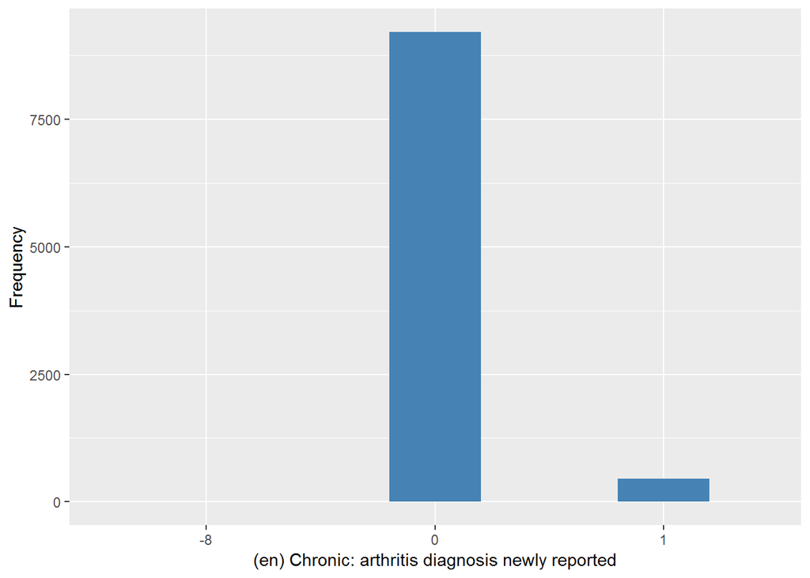

HeAgf

| Sample size | Missing values |
| --- | --- |
| 9666 | 9588 |

Summary

| Min. | 1st Qu. | Median | Mean | 3rd Qu. | Max. |
| --- | --- | --- | --- | --- | --- |
| 14 | 38.25 | 46.5 | 45.63 | 52 | 82 |

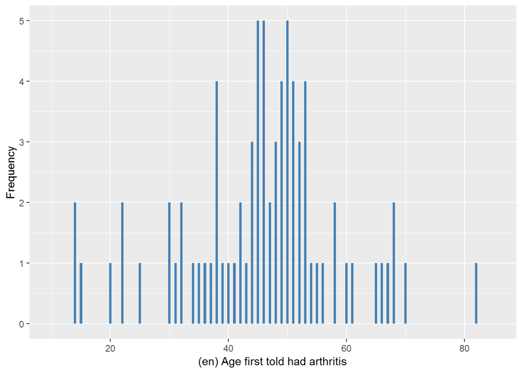

#### 2.1.7.2 Harmonisation algorithm

To compute `h_joint_disorders` from the study-specific variable it has to be recoded as follows:

- `h_joint_disorders previous == 1 or hedibar == 1 into 1`
- `h_joint_disorders previous == 0 and hedibar == 0 into 0`
- `h_joint_disorders previous == 0 and hedibar == -8 into 998`
- `otherwise into 999`

To compute `h_joint_disorders_age` from the study-specific variable it has to be recoded as follows:

- `if h_joint_disorders == 1, h_joint_disorders_age = HeAgf`
- `if h_joint_disorders == 0, h_joint_disorders_age = 996`
- `-9 into 997`
- `-8 into 998`
- `-1 into 996`
- `otherwise, h_joint_disorders_age = 999`

**R script:**

```r
ELSA_w7 <- left_join(ELSA_w7, ELSA_ds, by = "id")

# Categorical variable harmonization
ELSA_ds_w7 <- tibble(id = ELSA_w7$id)
ELSA_ds_w7$h_joint_disorders <- rep(999, length(ELSA_w7$id))
ELSA_ds_w7$h_joint_disorders[which((ELSA_w7$h_joint_disorders != 1 | is.na(ELSA_w7$h_joint_disorders)) &
    (ELSA_w7$hedibar == 0))] <- 0
ELSA_ds_w7$h_joint_disorders[which(ELSA_w7$h_joint_disorders == 1 | ELSA_w7$hedibar ==
    1)] <- 1
ELSA_ds_w7$h_joint_disorders[which((ELSA_w7$h_joint_disorders != 1 | is.na(ELSA_w7$h_joint_disorders)) &
    ELSA_w7$hedibar == -8)] <- 998

# Continuous variable harmonization
ELSA_ds_w7$h_joint_disorders_age <- rep(999, length(ELSA_w7$id))
ELSA_ds_w7$h_joint_disorders_age[which(ELSA_ds_w7$h_joint_disorders == 0)] <- 996
ELSA_ds_w7$h_joint_disorders_age[which(ELSA_ds_w7$h_joint_disorders == 1)] <- car::recode(ELSA_w7$HeAgf[which(ELSA_ds_w7$h_joint_disorders ==
    1)], "-1=996;-2=991;-8=998;-9=997")
ELSA_ds_w7$h_joint_disorders_age[which(ELSA_ds_w7$h_joint_disorders == 1 & !is.na(ELSA_w7$h_joint_disorders_age) &
    !ELSA_w7$h_joint_disorders_age %in% miss_values_vector)] <- ELSA_w7$h_joint_disorders_age[which(ELSA_ds_w7$h_joint_disorders ==
    1 & !is.na(ELSA_w7$h_joint_disorders_age) & !ELSA_w7$h_joint_disorders_age %in%
    miss_values_vector)]

# Update of global table
rm(ELSA_ds)
```

#### 2.1.7.3 Statistics of the new harmonized variable

History of arthritis, rheumatism or osteoarthritis

| Sample size | Missing values |
| --- | --- |
| 9666 | 2 |

Category

|  | 0 | 1 |
| --- | --- | --- |
| Frequency | 5635.0 | 4029.00 |
| Percentage | 58.3 | 41.68 |

Type of missing

|  | 991 | 992 | 993 | 994 | 995 | 996 | 997 | 998 | 999 | NA |
| --- | --- | --- | --- | --- | --- | --- | --- | --- | --- | --- |
| Frequency | 0 | 0 | 0 | 0 | 0 | 0 | 0 | 2.00 | 0 | 0 |
| Percentage | 0 | 0 | 0 | 0 | 0 | 0 | 0 | 0.02 | 0 | 0 |

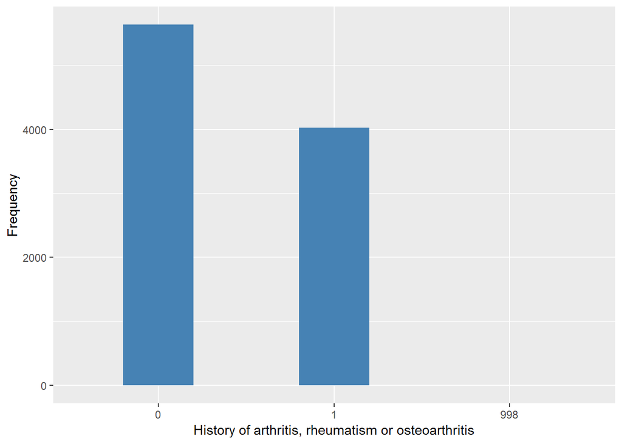

Age first diagnosed joint disorder

| Sample size | Missing values |
| --- | --- |
| 9666 | 7265 |

Values

|  | No-missings | 991 | 992 | 993 | 994 | 995 | 996 | 997 | 998 | 999 | NA |
| --- | --- | --- | --- | --- | --- | --- | --- | --- | --- | --- | --- |
| Frequency | 2401.00 | 0 | 0 | 0 | 0 | 0 | 7259.0 | 0 | 4.00 | 2.00 | 0 |
| Percentage | 24.84 | 0 | 0 | 0 | 0 | 0 | 75.1 | 0 | 0.04 | 0.02 | 0 |

Summary

| Min. | 1st Qu. | Median | Mean | 3rd Qu. | Max. |
| --- | --- | --- | --- | --- | --- |
| 0 | 44 | 50 | 49.78 | 58 | 88 |

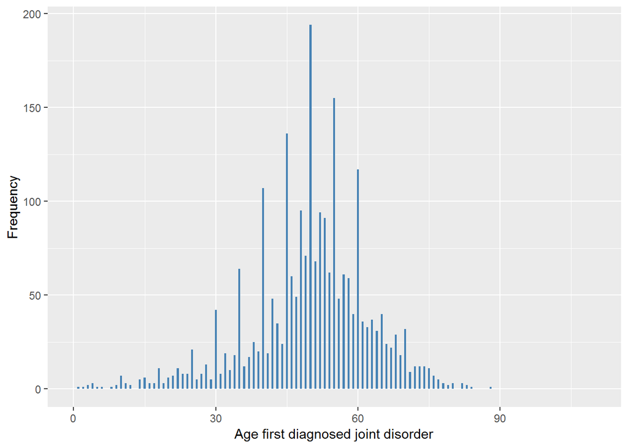

#### 2.1.7.4 Validation

|  | hedibar==0->0 | hedibar==1->1 | hedibar==-8->998 |
| --- | --- | --- | --- |
| BeforeH | 5635 | 4029 | 2 |
| AfterH | 5635 | 4029 | 2 |

## 2.2 Descriptive statistics of the harmonised variable `h_joint_disorders` accross populations and waves

Two tables are generated:

1. Percentages of categories in each harmonised variable.
2. Frequencies and percentages of individuals with different trajectories. To avoid too large table, Only trajectories with percentages larger than 0.3 are shown.

History of arthritis, rheumatism or osteoarthritis

| val | label | W1 | W2 | W3 | W4 | W5 | W6 | W7 |
| --- | --- | --- | --- | --- | --- | --- | --- | --- |
| 0 | No | 68.43 | 63.03 | 63.32 | 62.81 | 59.32 | 59.24 | 58.3 |
| 1 | Yes | 31.49 | 36.95 | 36.6 | 37.07 | 40.58 | 40.7 | 41.68 |
| 991 | CAPI interviewer error | 0 | 0 | 0 | 0 | 0 | 0 | 0 |
| 992 | Impute | 0 | 0 | 0 | 0 | 0 | 0 | 0 |
| 993 | Disable to measure | 0 | 0 | 0 | 0 | 0 | 0 | 0 |
| 994 | Not attempt not done | 0 | 0 | 0 | 0 | 0 | 0 | 0 |
| 995 | Does not answer | 0 | 0 | 0 | 0 | 0 | 0 | 0 |
| 996 | Not applicable | 0 | 0 | 0.08 | 0 | 0 | 0 | 0 |
| 997 | Refuse | 0.03 | 0.01 | 0 | 0.05 | 0.03 | 0.04 | 0 |
| 998 | Do not know | 0.05 | 0.01 | 0 | 0.07 | 0.07 | 0.02 | 0.02 |
| 999 | Missing | 0 | 0 | 0 | 0 | 0 | 0 | 0 |
| NA | NA | 0 | 0 | 0 | 0 | 0 | 0 | 0 |
| n | sample size | 12099 | 9432 | 9771 | 11050 | 10274 | 10601 | 9666 |

|  | val | frq | raw.prc |
| --- | --- | --- | --- |
| 1 | 0000000 | 2094 | 11.33 |
| 2 | 0000001 | 119 | 0.64 |
| 3 | 000000NA | 303 | 1.64 |
| 4 | 0000011 | 136 | 0.74 |
| 8 | 00000NANA | 225 | 1.22 |
| 9 | 0000111 | 150 | 0.81 |
| 19 | 0000NANANA | 308 | 1.67 |
| 20 | 0001111 | 169 | 0.91 |
| 28 | 000NA000 | 59 | 0.32 |
| 44 | 000NANANANA | 518 | 2.80 |
| 45 | 0011111 | 197 | 1.07 |
| 57 | 00NA0000 | 62 | 0.34 |
| 89 | 00NANANANANA | 777 | 4.20 |
| 90 | 0111111 | 254 | 1.37 |
| 115 | 01NANANANANA | 81 | 0.44 |
| 140 | 0NA0NANANANA | 65 | 0.35 |
| 187 | 0NANANANANANA | 1393 | 7.53 |
| 188 | 1111111 | 1256 | 6.79 |
| 189 | 111111NA | 223 | 1.21 |
| 191 | 11111NANA | 189 | 1.02 |
| 195 | 1111NANANA | 222 | 1.20 |
| 202 | 111NANANANA | 329 | 1.78 |
| 217 | 11NANANANANA | 434 | 2.35 |
| 245 | 1NANANANANANA | 685 | 3.70 |
| 281 | NANA00000 | 591 | 3.20 |
| 283 | NANA0000NA | 78 | 0.42 |
| 288 | NANA000NANA | 68 | 0.37 |
| 297 | NANA00NANANA | 106 | 0.57 |
| 319 | NANA0NANANANA | 255 | 1.38 |
| 320 | NANA11111 | 130 | 0.70 |
| 334 | NANANA0000 | 1028 | 5.56 |
| 335 | NANANA0001 | 59 | 0.32 |
| 336 | NANANA000NA | 165 | 0.89 |
| 337 | NANANA0011 | 77 | 0.42 |
| 341 | NANANA00NANA | 125 | 0.68 |
| 342 | NANANA0111 | 90 | 0.49 |
| 353 | NANANA0NANANA | 276 | 1.49 |
| 354 | NANANA1111 | 451 | 2.44 |
| 355 | NANANA111NA | 72 | 0.39 |
| 361 | NANANA1NANANA | 87 | 0.47 |
| 362 | NANANANA000 | 55 | 0.30 |
| 373 | NANANANANA00 | 756 | 4.09 |
| 375 | NANANANANA0NA | 226 | 1.22 |
| 376 | NANANANANA11 | 166 | 0.90 |
| 378 | NANANANANANA0 | 446 | 2.41 |
| 379 | NANANANANANA1 | 64 | 0.35 |

## 2.3 Summary of descriptive statistics of the harmonised variable `h_joint_disorders_age` accross populations and waves

Age first diagnosed joint disorder

| h_joint_disorders_age | W1 | W2 | W3 | W4 | W5 | W6 | W7 |
| --- | --- | --- | --- | --- | --- | --- | --- |
| Min. | 0 | 0 | 0 | 0 | 0 | 0 | 0 |
| 1st Qu. | 45 | 45 | 45 | 45 | 45 | 45 | 44 |
| Median | 54 | 54 | 53 | 52 | 52 | 51 | 50 |
| Mean | 53.83 | 53.53 | 52.29 | 51.77 | 51.32 | 50.4 | 49.78 |
| 3rd Qu. | 63 | 62 | 60 | 60 | 60 | 58 | 58 |
| Max. | 92 | 92 | 92 | 90 | 88 | 88 | 88 |
| No-missings | 3735 | 2902 | 2737 | 3026 | 2801 | 2727 | 2401 |
| 991 | 0 | 0 | 0 | 7 | 0 | 0 | 0 |
| 992 | 0 | 0 | 0 | 0 | 0 | 0 | 0 |
| 993 | 0 | 0 | 0 | 0 | 0 | 0 | 0 |
| 994 | 0 | 0 | 0 | 0 | 0 | 0 | 0 |
| 995 | 0 | 0 | 0 | 0 | 0 | 0 | 0 |
| 996 | 8279 | 6528 | 7023 | 7987 | 7463 | 7865 | 7259 |
| 997 | 0 | 0 | 0 | 0 | 0 | 0 | 0 |
| 998 | 75 | 0 | 3 | 17 | 0 | 3 | 4 |
| 999 | 10 | 2 | 8 | 13 | 10 | 6 | 2 |
| NA | 0 | 0 | 0 | 0 | 0 | 0 | 0 |
| sample size | 12099 | 9432 | 9771 | 11050 | 10274 | 10601 | 9666 |

# 3 Quality estimation

- We assume that if an individual answers it has joint disorders in one wave, it has for all the next waves.
- We have found three individuals which report to have been diagnosed joint disorders being 0 years-old. We have keep this data after harmonisation.

In wave 1

| id | hedib01 | heagf |
| --- | --- | --- |
| 112430 | 3 | 0 |

In wave 4

| id | hedibar | heagf |
| --- | --- | --- |
| 160458 | 1 | 0 |
| 161853 | 1 | 0 |